# Data Management I

# Agenda

- Variable Types
- Frequency Distributions
- `dplyr` I
- Summary Statistics

# Learning objectives

By the end of the lecture, you will be able to …

- identify and convert variable types
- create useful frequency tables
- implement some basic variable manipulation
- produce measures of central tendency and variability

# Code-along 02

[Download code-along-02.qmd](https://www.dropbox.com/scl/fi/w4q8k770w8u6vsce8sf9g/code-along-02.qmd?rlkey=3muxn4lgthaw1sasoqnah0sy4&dl=1)

## Mini-task

Install the [`summarytools()`](https://cran.r-project.org/web/packages/summarytools/vignettes/introduction.html) package, available on CRAN.

**Run the code chunk in your code-along.**

*OR:* Copy and paste the code into your Console pane. Then hit “Enter”.

```r
install.packages("summarytools")
```

## Mini-task

Load the standard packages and our new `summarytools()` package.

```r
library(tidyverse)
library(haven) # not core tidyverse
library(gssr)
library(gssrdoc) # load the GSS codebook
library(summarytools)
```

## Mini-task

Load the 2024 GSS data & all survey waves.

```r
# Get the data only for the 2024 survey respondents
gss24 <- gss_get_yr(2024)

# Get the data all survey years
data(gss_all)
```

Use the `gss_which_years()` function to identify the survey years a variable appeared.

```r
gss_which_years(gss_all, meovrwrk)
```

```
# A tibble: 35 × 2
   year      meovrwrk
   <dbl+lbl> <lgl>
 1 1972      FALSE
 2 1973      FALSE
 3 1974      FALSE
 4 1975      FALSE
 5 1976      FALSE
 6 1977      FALSE
 7 1978      FALSE
 8 1980      FALSE
 9 1982      FALSE
10 1983      FALSE
# ℹ 25 more rows
```

**Heads Up!**

If run in the console, to see all rows, wrap the code in the `print()` command: `print(gss_which_years(gss_all, meovrwrk), n = 40)`

## Mini-task

Which survey years did the variable `childs` appear?

```r
gss_which_years(gss_all, childs)
```

```
# A tibble: 35 × 2
   year      childs
   <dbl+lbl> <lgl>
 1 1972      TRUE
 2 1973      TRUE
 3 1974      TRUE
 4 1975      TRUE
 5 1976      TRUE
 6 1977      TRUE
 7 1978      TRUE
 8 1980      TRUE
 9 1982      TRUE
10 1983      TRUE
# ℹ 25 more rows
```

# Variable Types

## Data types in R

A property is assigned to objects that determines how generic functions operate with it.

Common ‘types’ or ‘classes’ of variables:

- **logical**
- **character**
- **integer**
- **numeric**
- and more, but we won’t be focusing on those

## Data class + variable type

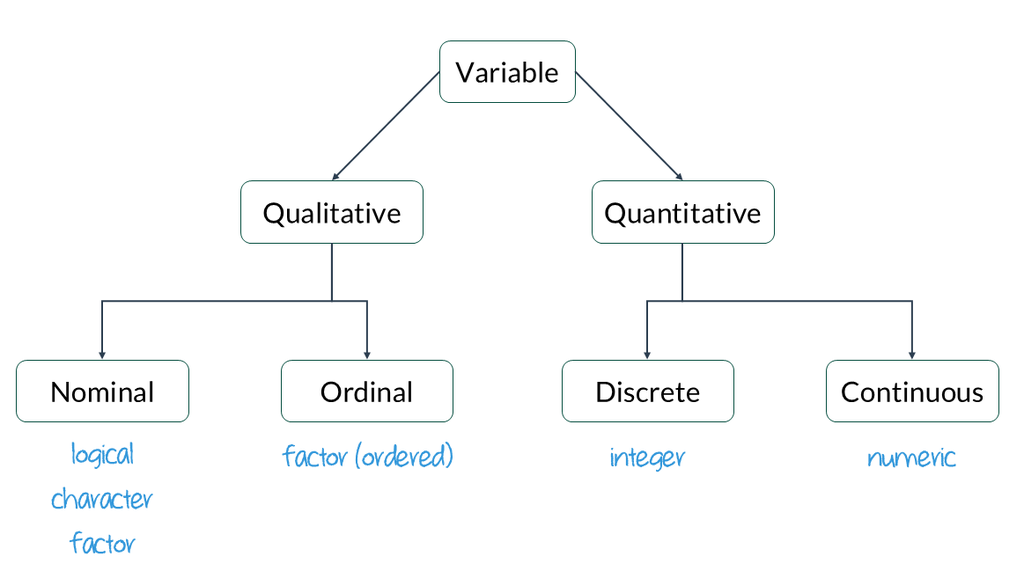

## `class()`

**logical** - Boolean values `TRUE` and `FALSE`

```r
class(TRUE)
```

```
[1] "logical"
```

**character** - character strings

```r
class("Sociology")
```

```
[1] "character"
```

**Integer** - numeric data without decimals  
(indicated with an `L`).

```r
class(2L)
```

```
[1] "integer"
```

**numeric** - default type if values are numbers or if the values contain decimals.

```r
class(2.5)
```

```
[1] "numeric"
```

## Factor

**factors** consist of character data with a fixed and known set of possible values

```r
opinion <- factor(c("like", "dislike", "dislike", "hate", "dislike", "hate"))
class(opinion)
```

```
[1] "factor"
```

```r
# By default, the levels are sorted alphabetically.
levels(opinion)
```

```
[1] "dislike" "hate"    "like"
```

## Factor order

```r
# Reorder the levels with the argument `levels` in the `factor()` function
opinion <- factor(opinion, levels = c("hate", "dislike", "like"))
levels(opinion)
```

```
[1] "hate"    "dislike" "like"
```

```r
# If the order has meaning (like rankings), you can make it an ordered factor
opinion <- factor(opinion, levels = c("hate", "dislike", "like"), ordered = TRUE)
levels(opinion)
```

```
[1] "hate"    "dislike" "like"
```

## Converting between types

Use a function: `as.logical()`, `as.numeric()`, `as.integer()`, or `as.character()`.

Create a numeric variable.

```r
x <- 1:3
x
```

```
[1] 1 2 3
```

```r
class(x)
```

```
[1] "integer"
```

**Heads Up!**

The : (colon) means ‘through.’

Change it to a character variable.

```r
y <- as.character(x)
y
```

```
[1] "1" "2" "3"
```

```r
class(y)
```

```
[1] "character"
```

**Heads Up!**

Notice the quotation marks around the values.

## Haven labelled

When you import data into R from software like SPSS, Stata, or SAS, you might notice a special class called `haven_labelled`.

```r
class(gss24$premarsx)
```

```
[1] "haven_labelled" "vctrs_vctr"     "double"
```

```r
table(gss24$premarsx)
```

```
   1    2    3    4
 438  172  317 1633
```

## Haven labelled cont.

It makes data easier to understand without needing a separate codebook.

```r
attr(gss24$premarsx, "label")
print_labels(gss24$premarsx)
```

**1**

A description of the variable

**2**

View the label attached to each numeric value

```
[1] "Sex before marriage"

Labels:
 value                         label
     1                  always wrong
     2           almost always wrong
     3          wrong only sometimes
     4              not wrong at all
     5                         other
 NA(d)                    don't know
 NA(i)                           iap
 NA(j)            I don't have a job
 NA(m)                   dk, na, iap
 NA(n)                     no answer
 NA(p)                 not imputable
 NA(r)                       refused
 NA(s)                skipped on web
 NA(u)                    uncodeable
 NA(x) not available in this release
 NA(y)    not available in this year
 NA(z)                  see codebook
```

You can use [`as_factor`](https://haven.tidyverse.org/reference/as_factor.html) to see the value labels of the variable `premarsx`.

- Mini-task
- with `as_factor()`
- without `as_factor()`

Use `as_factor()` inside the `table()` function for the variable `premarsx`

```r
table(as_factor(gss24$premarsx), useNA = "ifany")
```

```
                 always wrong           almost always wrong
                          438                           172
         wrong only sometimes              not wrong at all
                          317                          1633
                        other                           iap
                            0                          1351
                   don't know            I don't have a job
                           50                             0
                  dk, na, iap                     no answer
                            0                             6
                not imputable                       refused
                            0                             0
               skipped on web                    uncodeable
                           19                             0
not available in this release    not available in this year
                            0                             0
                 see codebook
                            0
```

```r
table(gss24$premarsx, useNA = "ifany")
```

```
   1    2    3    4 <NA>
 438  172  317 1633 1426
```

## Convert labels to factors

- `zap_missing()`
- `as_factor()`
- `droplevels()`

1. Use `zap_missing()` to get rid of all the ‘missing’ (NA) levels

```r
gss24$premarsx <- zap_missing(gss24$premarsx)
table(as_factor(gss24$premarsx), useNA = "ifany") # see the results
```

```
        always wrong  almost always wrong wrong only sometimes
                 438                  172                  317
    not wrong at all                other                 <NA>
                1633                    0                 1426
```

2. Use `as_factor()` to apply the labels instead of numeric values

```r
gss24$premarsx <- as_factor(gss24$premarsx) # replace the values with labels
table(gss24$premarsx, useNA = "ifany") # notice we didn't need to wrap the variable in as_factor
```

```
        always wrong  almost always wrong wrong only sometimes
                 438                  172                  317
    not wrong at all                other                 <NA>
                1633                    0                 1426
```

3. Use `droplevels()` to get rid of the empty levels in `premarsx`.

```r
gss24$premarsx <- droplevels(gss24$premarsx)
table(gss24$premarsx)
```

```
        always wrong  almost always wrong wrong only sometimes
                 438                  172                  317
    not wrong at all
                1633
```

## Mini-task

Use `zap_missing()`, `as_factor()`, & `droplevels()` on the variable `sex`.

```r
gss24$sex <- zap_missing(gss24$sex)
gss24$sex <- as_factor(gss24$sex)
gss24$sex <- droplevels(gss24$sex)

table(gss24$sex)
```

**1**

Get rid of all the ‘missing’ (NA) levels.

**2**

Replace the values with labels.

**3**

Get rid of the empty levels (if any).

```
  male female
  1787   2169
```

# Frequency Distributions

## Relative frequency table

Let’s try functions from the `summarytools()` package to get univariate (1 variable) and bivariate (2 variables) descriptive statistics.

`freq()` creates table of the counts for a variable.

```r
freq(gss24$sex)
```

```
Frequencies
gss24$sex
Type: Factor

               Freq   % Valid   % Valid Cum.   % Total   % Total Cum.
------------ ------ --------- -------------- --------- --------------
        male   1787     45.17          45.17     44.83          44.83
      female   2169     54.83         100.00     54.42          99.25
        <NA>     30                               0.75         100.00
       Total   3986    100.00         100.00    100.00         100.00
```

## Mini-task

Use `freq()` on the variable `premarsx`

```r
freq(gss24$premarsx)
```

```
Frequencies
gss24$premarsx
Type: Factor

                             Freq   % Valid   % Valid Cum.   % Total   % Total Cum.
-------------------------- ------ --------- -------------- --------- --------------
              always wrong    438     17.11          17.11     10.99          10.99
       almost always wrong    172      6.72          23.83      4.32          15.30
      wrong only sometimes    317     12.38          36.21      7.95          23.26
          not wrong at all   1633     63.79         100.00     40.97          64.22
                      <NA>   1426                              35.78         100.00
                     Total   3986    100.00         100.00    100.00         100.00
```

## Pretty tables

One of `summarytools` main purposes is to help clean and prepare data for further analysis. But sometimes we don’t care about the missing values.

Using `report.nas = FALSE` suppresses the missing data.  
The `headings = FALSE` parameter suppresses the heading section.

```r
freq(gss24$sex, report.nas = FALSE, headings = FALSE)
```

```
               Freq        %   % Cum.
------------ ------ -------- --------
        male   1787    45.17    45.17
      female   2169    54.83   100.00
       Total   3956   100.00   100.00
```

## Mini-task

Make a pretty frequency table for the variable `premarsx`.

```r
freq(gss24$premarsx, report.nas = FALSE, headings = FALSE)
```

```
                             Freq        %   % Cum.
-------------------------- ------ -------- --------
              always wrong    438    17.11    17.11
       almost always wrong    172     6.72    23.83
      wrong only sometimes    317    12.38    36.21
          not wrong at all   1633    63.79   100.00
                     Total   2560   100.00   100.00
```

## Cross-tabs

We’ve been using the `table()` function with one variable at a time, but it also let’s you create a frequency table (**crosstab**) with two variables.

```r
# 1st variable is the rows, 2nd variable is the columns.
table(gss24$premarsx, gss24$sex)
```

```
                       male female
  always wrong          180    256
  almost always wrong    71     98
  wrong only sometimes  155    161
  not wrong at all      734    891
```

But it’s missing the **column** percentages…

## Relative frequency by group

To run `freq()` by group, pair it with the `stby()` function.

```r
stby(gss24$premarsx, gss24$sex, freq)
```

```
Frequencies
gss24$premarsx
Type: Factor
Group: sex = male

                             Freq   % Valid   % Valid Cum.   % Total   % Total Cum.
-------------------------- ------ --------- -------------- --------- --------------
              always wrong    180     15.79          15.79     10.07          10.07
       almost always wrong     71      6.23          22.02      3.97          14.05
      wrong only sometimes    155     13.60          35.61      8.67          22.72
          not wrong at all    734     64.39         100.00     41.07          63.79
                      <NA>    647                              36.21         100.00
                     Total   1787    100.00         100.00    100.00         100.00

Group: sex = female

                             Freq   % Valid   % Valid Cum.   % Total   % Total Cum.
-------------------------- ------ --------- -------------- --------- --------------
              always wrong    256     18.21          18.21     11.80          11.80
       almost always wrong     98      6.97          25.18      4.52          16.32
      wrong only sometimes    161     11.45          36.63      7.42          23.74
          not wrong at all    891     63.37         100.00     41.08          64.82
                      <NA>    763                              35.18         100.00
                     Total   2169    100.00         100.00    100.00         100.00
```

This is hard to read and we don’t need the cumulative frequencies.

## Pretty cross-tabs with `ctable()`

Use `summarytools::ctable` instead!

```r
ctable(gss24$premarsx, gss24$sex,
  prop = "c",
  format = "p",
  useNA = "no"
)
```

**1**

Change from `table()` to `ctable()`.

**2**

The “c” gives column %; “r” would give row %.

**3**

This adds the % symbols to the table.

**4**

Exclude the missing levels from the table.

```
Cross-Tabulation, Column Proportions
premarsx * sex
Data Frame: gss24

---------------------- ----- --------------- --------------- ---------------
                         sex            male          female           Total
              premarsx
          always wrong          180 ( 15.8%)    256 ( 18.2%)    436 ( 17.1%)
   almost always wrong           71 (  6.2%)     98 (  7.0%)    169 (  6.6%)
  wrong only sometimes          155 ( 13.6%)    161 ( 11.5%)    316 ( 12.4%)
      not wrong at all          734 ( 64.4%)    891 ( 63.4%)   1625 ( 63.8%)
                 Total         1140 (100.0%)   1406 (100.0%)   2546 (100.0%)
---------------------- ----- --------------- --------------- ---------------
```

Based on your table, what percentage of respondents believe sex before marriage is ‘almost always wrong’?

- 5.7
- 16.8
- 121
- 12.2

Based on your table, do a greater percentage of men or women think sex before marriage is ‘not wrong at all’?

- Men
- Women

# dplyr I

## Tidying Data

Most tasks related to data analysis are not glorious or fancy.

A lot of time is dedicated to whipping a dataset into the shape needed to be able to analyze it.

This task has different names “*data cleaning*,” “*data management*,” “*data manipulation*,” “*data wrangling*,” “*data transformation*.”

Source: [Jasper Dag Tjaden](https://jaspertjaden.github.io/course-intro2r/week3.html)

## `dplyr` package

The `dplyr` package provides a complete set of functions that help you solve the most common data manipulation challenges:

- **filtering** observations based on their values
- **extracting** observations based on their values or positions
- **sampling** observations based on a specific number or fraction of rows
- **sorting** observations based on one or several variables
- **selecting** variables based on their names or positions
- **renaming** variables
- **adding** new variables based on existing ones
- **summarizing** observations or variables to a single descriptive measure
- performing any operation by **grouping**

Source: [Antoine Soetewey](https://statsandr.com/blog/introduction-to-data-manipulation-in-r-with-dplyr/)

## `function`(argument)

Functions are (most often) verbs, followed by what they will be applied to in parentheses:

```r
do_this(to_this)
do_that(to_this, to_that, with_those)
```

`dplyr` verbs (functions) will allow you to solve the vast majority of your data manipulation challenges.

Source: [Dr. Mine Çetinkaya-Rundel](https://sta199-f24.github.io/slides/01-meet-the-toolkit-slides.html#/functionargument)

## `dplyr` basics

They are organized into four groups based on what they operate on: rows, columns, groups, or tables.

**The verbs all have in common**:

1. The first argument is always a data frame.
2. The subsequent arguments typically describe which columns to operate on using the variable names (without quotes).
3. The output is always a new data frame.

Source: [R for Data Science](https://r4ds.hadley.nz/data-transform.html#the-pipe)

## The pipe `|>`

The pipe operator passes what comes before it into the function that comes after it as the first argument.

```r
sum(1, 2)
```

```
[1] 3
```

```r
1 |>
  sum(2)
```

```
[1] 3
```

## `dplyr()` in action

Create a frequency table for `childs` variable.

```r
gss_all$childs <- zap_missing(gss_all$childs)
gss_all$childs <- as_factor(gss_all$childs)
gss_all$childs <- droplevels(gss_all$childs)

gss_all |>
  freq(childs, report.nas = FALSE) |>
  tb()
```

**1**

Use `dplyr` grammar, starting with the name of the df and a pipe

**2**

Use the `freq()` function as usual

**3**

Add the `tb()` function to turn the table into a `tibble`

How many children have you ever had? Please count all that were born alive at any time (including any you had from a previous marriage).

## `dplyr()` in action

```
# A tibble: 9 × 4
  childs     freq    pct pct_cum
  <fct>     <dbl>  <dbl>   <dbl>
1 0         20956 27.8      27.8
2 1         11979 15.9      43.7
3 2         18989 25.2      68.9
4 3         11671 15.5      84.3
5 4          5996  7.95     92.3
6 5          2669  3.54     95.8
7 6          1381  1.83     97.7
8 7           734  0.973    98.6
9 8 or more  1032  1.37    100
```

## Mini-task

Use a `|>` & `gss_which_years()` to find out which survey years the variable `agekdbrn` appears.

```r
gss_all |>
  gss_which_years(agekdbrn)
```

```
# A tibble: 35 × 2
   year      agekdbrn
   <dbl+lbl> <lgl>
 1 1972      FALSE
 2 1973      FALSE
 3 1974      FALSE
 4 1975      FALSE
 5 1976      FALSE
 6 1977      FALSE
 7 1978      FALSE
 8 1980      FALSE
 9 1982      FALSE
10 1983      FALSE
# ℹ 25 more rows
```

## `dplyr` style

In data transformation pipelines, always use a

- space before `|>`
- line break after `|>`
- indent the next line of code

We’ll talk about data visualization pipes later…

**Heads Up!**

|> (native pipe operator) and %>% (magrittr package) behave identically for simple cases. More info.

## `dplyr` grammar

What’s the advantage of [`dplyr`](https://cran.r-project.org/web/packages/dplyr/readme/README.html) grammar? We can sequence data manipulation!

```r
gss_all |>
  filter(year == 2022) |>
  drop_na(sex, agekdbrn) |>
  group_by(sex) |>
  summarize(avg = mean(agekdbrn))
```

```
# A tibble: 2 × 2
  sex          avg
  <dbl+lbl>  <dbl>
1 1 [male]    26.3
2 2 [female]  23.7
```

## `filter()` & `drop_na()`

Use `filter()` to keep rows that meet a condition.  
Use `drop_na()` to remove rows with missing (NA) values.

```r
gss_all |>
  filter(year == 2022) |>
  drop_na(sex, agekdbrn)|>
  count(sex)
```

**1**

Start with the `gss_all` data frame:

**2**

Keep only the respondents from the 2022 survey

**3**

Remove any observations with missing data for our key variables

**4**

Tally how many complete entries remain for each gender

```
# A tibble: 2 × 2
  sex            n
  <dbl+lbl>  <int>
1 1 [male]    1031
2 2 [female]  1363
```

## Mini-task

Limit the dataframe to only the 2024 respondents without missing data for `sex`, `hrs1`, and `childs`. How many men and women are left?

```r
gss_all |>
  filter(year == 2024) |>
  drop_na(sex, hrs1, childs) |>
  count(sex)
```

```
# A tibble: 2 × 2
  sex            n
  <dbl+lbl>  <int>
1 1 [male]     859
2 2 [female]   888
```

# Summary Statistics

## Median & Mean w base R

```r
# Using base R
median(gss_all$agekdbrn, na.rm=TRUE)
```

**1**

`na.rm` is a logical evaluating to `TRUE` or `FALSE` indicating whether `NA` values should be stripped before the computation proceeds.

```
[1] 23
```

```r
mean(gss_all$agekdbrn, na.rm=TRUE)
```

```
[1] 24.14491
```

```r
# show me summary statistics
summary(gss_all$agekdbrn)
```

```
   Min. 1st Qu.  Median    Mean 3rd Qu.    Max.     NAs
   9.00   20.00   23.00   24.14   28.00   97.00   46832
```

Question 14. How old were you when your first child was born?

## Mini-task

Find the mean and median for the variable: `hrs1`.

```r
# separately
median(gss_all$hrs1, na.rm=TRUE)
mean(gss_all$hrs1, na.rm=TRUE)

# together
summary(gss_all$hrs1)
```

```
[1] 40
[1] 41.11279
   Min. 1st Qu.  Median    Mean 3rd Qu.    Max.     NAs
   0.00   37.00   40.00   41.11   48.00   89.00   32371
```

Question 1a. If working, full or part time: how many hours did you work last week, at all jobs?

## `summarize()`

Use functions inside `summarize()` to create summary variables.

```r
gss_all |>
  drop_na(agekdbrn) |>
   summarize(
    avg = mean(agekdbrn)
    )
```

```
# A tibble: 1 × 1
    avg
  <dbl>
1  24.1
```

## Median & Mean with `dplyr`

Use dplyr grammar to find the frequency, mean, and median.

Add lots of summary variables using functions inside `summarize()`.

```r
gss_all |>
  drop_na(agekdbrn) |>
  summarize(
    freq = n(),
    med = median(agekdbrn),
    avg = mean(agekdbrn)
    )
```

**1**

Use `n()` function to create a count variable (no variable in parentheses)

**2**

Use `median()` function on a variable

**3**

Use `mean()` function on a variable

```
# A tibble: 1 × 3
   freq   med   avg
  <int> <dbl> <dbl>
1 28867    23  24.1
```

## Mini-task

Use `dplyr` grammar to find the frequency, mean, and median for the variable: `hrs1`.

```r
gss_all |>
  drop_na(hrs1) |>
   summarize(
    freq = n(),
    med = median(hrs1),
    avg = mean(hrs1)
    )
```

```
# A tibble: 1 × 3
   freq   med   avg
  <int> <dbl> <dbl>
1 43328    40  41.1
```

## `group_by()` and `summarize()`

Use `group_by()` to organize your data into groups based on one or more variables.  
Use `summarize()` to compute statistics like total, mean, or median for each group.

```r
gss_all |>
  drop_na(sex, agekdbrn) |>
  group_by(sex) |>
  summarize(avg = mean(agekdbrn))
```

**1**

Start with the `gss_all` data frame:

**2**

Remove any observations with missing data for our key variables

**3**

Do the next steps separately for each group in the variable

**4**

Creates a new data frame with one row for each combination of grouping variables

```
# A tibble: 2 × 2
  sex          avg
  <dbl+lbl>  <dbl>
1 1 [male]    25.7
2 2 [female]  23.0
```

## Mini-task

Compare the median and average work hours (`hrs1`) for U.S. men and women.

```r
gss_all |>
  drop_na(sex, hrs1) |>
  group_by(sex) |>
  summarize(
    med = median(hrs1),
    avg = mean(hrs1)
    )
```

```
# A tibble: 2 × 3
  sex          med   avg
  <dbl+lbl>  <dbl> <dbl>
1 1 [male]      40  44.3
2 2 [female]    40  37.8
```

## `summarize()` + variability measures

```r
gss_all |>
  drop_na(agekdbrn, sex)  |>
  group_by(as_factor(sex)) |>
  summarize(
    freq = n(),
    min = min(agekdbrn),
    median = median(agekdbrn),
    max = max(agekdbrn),
    mean = round(mean(agekdbrn), digits = 2),
    sd = sd(agekdbrn)
    )
```

```
# A tibble: 2 × 7
  `as_factor(sex)`  freq min       median max        mean    sd
  <fct>            <int> <dbl+lbl>  <dbl> <dbl+lbl> <dbl> <dbl>
1 male             11790 9             25 65         25.7  5.85
2 female           17009 9             22 57         23.0  5.30
```

# Think Like a Statistician

How did the mean and standard deviation of weekly work hours differ between men and women in 2024, and what do these differences suggest about gender-based variability in labor patterns?

**How do we find out?**

## Think Like a Statistician

**Can you produce this table?**

```
# A tibble: 2 × 3
  `as_factor(sex)`  mean    sd
  <fct>            <dbl> <dbl>
1 male              41.7  13.7
2 female            37.3  13.7
```

## Your Data Take

**What’s your conclusion to our research question?**